# First observations

With this tutorial, we have a working example website that we will explore together. We’ll learn a few rules and look for patterns to get an understanding of what things do. And you can continue to use this website as a reference after the tutorial, along with [**RStudio’s instructions for R Markdown websites**](http://rmarkdown.rstudio.com/rmarkdown_websites.html).

We’ll start our exploration online looking at the website architecture, then we’ll clone the repo to our local computers. Locally, we will explore further by going back and forth between the R Markdown editor and built webpages, and make modifications. Pushing to Github will make our modifications live!

## Exploring online

### The website itself

This website has 5 pages:

- Home
- First Observations
- Basic Workflow
- Getting Sophisticated
- Your Turn

`github.io` means that there is a Github repo behind this website, and we also know the username and repo name:

**http://jules32.github.io/rmarkdown-website-tutorial** <=> **https://github.com/jules32/rmarkdown-website-tutorial**

(Note: you can have github websites point to different urls if you don’t want the `github.io`.)

### The website’s repo

Let’s go to **https://github.com/jules32/rmarkdown-website-tutorial**.

**First, note the `gh-pages` branch** - this is critical for building free webpages. You can usually name branches whatever you want, but the `gh-pages` name means it can be built as a website. [I set it as my default branch](https://help.github.com/articles/setting-the-default-branch/).

[figure not shown]

**Now let’s look at the filenames**. We can recognize the names of the webpages we’ve seen, and there is also a `_site.yml` file, which is the website’s configuration file. The simplest website possible would have 2 files only: `_site.yml` and `index.Rmd`

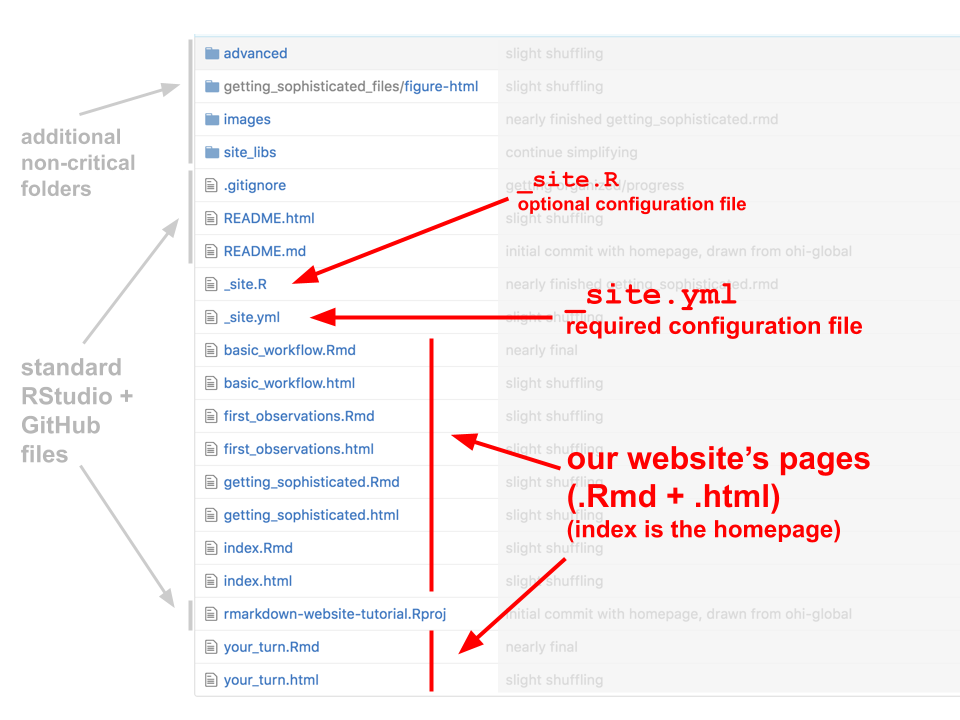

## Fork to your account, clone to your computer

Let’s start digging deeper and playing with this.

1. Fork the jules32/rmarkdown-website-tutorial repo into your own account.
2. Edit the URL for the website by replacing `jules32` with your GitHub username
3. Clone to your local computer using RStudio (preferred) the [Desktop App](https://desktop.github.com/), or the command line.

[figure not shown]